# Data Analysis

Andrew Hashoush

2024-01-05

Data Description: The data in the file “UN.txt” contains PPgdp, the 2001 gross national product per person in US dollars, and Fertility, the birth rate per 1000 femals in the population in the year 2000. The data are for 184 localities, mostly UN member countries, but also other areas such as Hong Kong that are not independent countries. In this problem, we study the relationship between Fertility and PPgdp.

## Loading the dataset

```r
setwd("~/Downloads")
un <- read_table("UN.txt")
un
```

```
## # A tibble: 184 × 3
##    Locality    Fertility PPgdp
##    <chr>           <dbl> <dbl>
##  1 Afghanistan      6.8     98
##  2 Albania          2.28  1317
##  3 Algeria          2.8   1784
##  4 Angola           7.2    739
##  5 Argentina        2.44  7163
##  6 Australia        1.7  18788
##  7 Austria          1.28 23260
##  8 Azerbaijan       2.1    695
##  9 Bahamas          2.29 14856
## 10 Bahrain          2.66 12012
## # ℹ 174 more rows
```

## Scatterplot of Fertility versus PPgdp

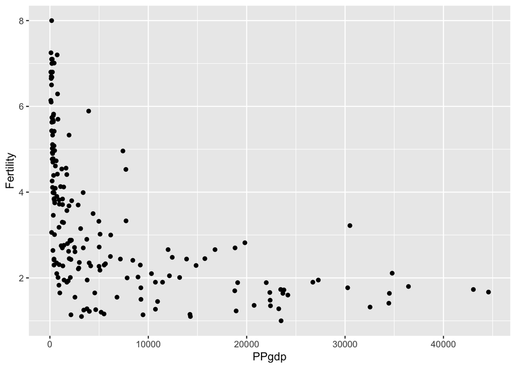

```r
n=nrow(un)

ggplot(un, aes(x = PPgdp, y = Fertility)) +
  geom_point()
```

The relationship between Fertility and GDP per person is clearly non-linear. The scale is changing wildly so we consider using the log-transformation. The simple linear regression would not be a good model to summarize the raw data in this graph.

## Transformation

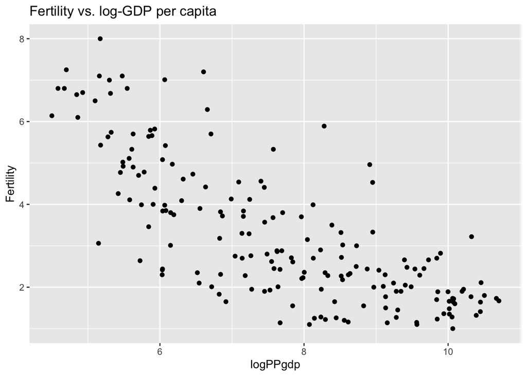

```r
un$logFertility=log(un$Fertility)
un$logPPgdp=log(un$PPgdp)

ggplot(un, aes(x = logPPgdp, y = Fertility)) +
  geom_point() +
  ggtitle("Fertility vs. log-GDP per capita")
```

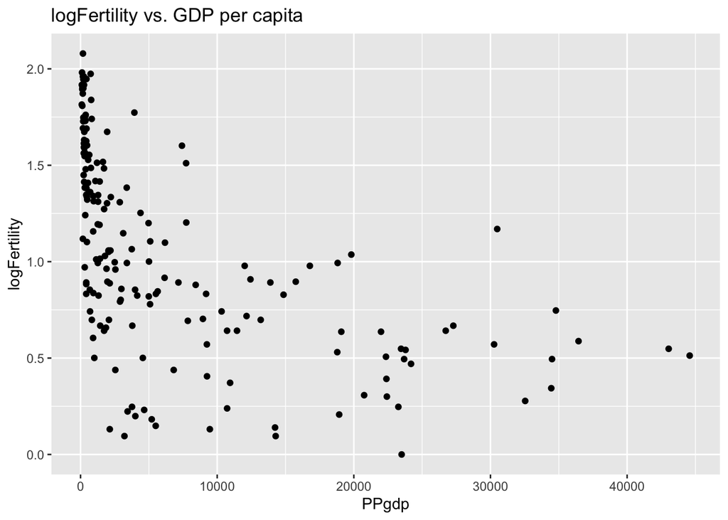

```r
ggplot(un, aes(x = PPgdp, y = logFertility)) +
  geom_point() +
  ggtitle("logFertility vs. GDP per capita")
```

This first one is nearly linear but looking close you can see a sort of bend toward the larger x-values.

Now will try logging both variables to get a more linear relationship

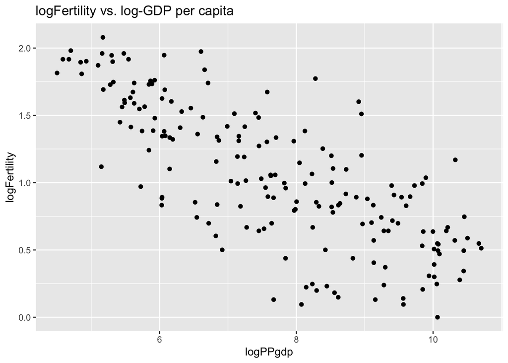

```r
ggplot(un, aes(x = logPPgdp, y = logFertility)) +
  geom_point() +
  ggtitle("logFertility vs. log-GDP per capita")
```

## Fitting the Model

```r
y=un$logFertility
x=un$logPPgdp
ybar=mean(y)
xbar=mean(x)
SSY=sum((y-ybar)^2)
SSX=sum((x-xbar)^2)
SSXY=sum((x-xbar)*(y-ybar))
betahat1=SSXY/SSX
betahat0=ybar-betahat1*xbar
betahat0
```

```
## [1] 2.876072
```

```r
betahat1
```

```
## [1] -0.2374852
```

```r
R2=betahat1^2*SSX/SSY #=SSR/SSTO
R2
```

```
## [1] 0.5813292
```

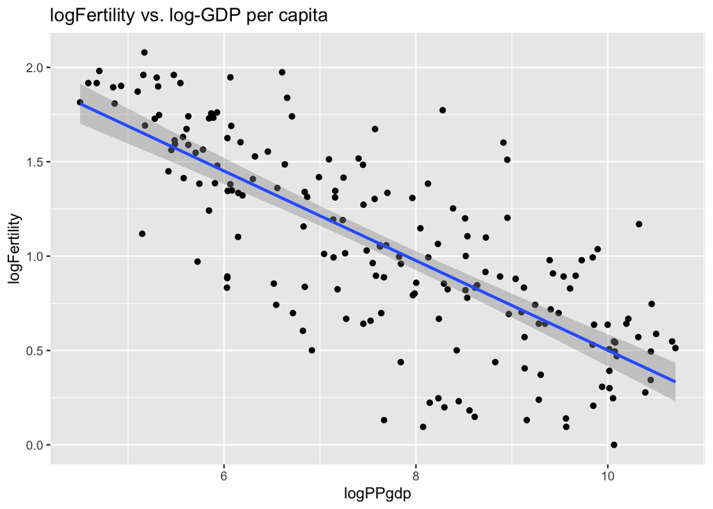

```r
ggplot(un, aes(x = logPPgdp, y = logFertility)) +
  geom_point() +
  geom_smooth(method = "lm") +
  ggtitle("logFertility vs. log-GDP per capita")
```

## Diagnostic plots

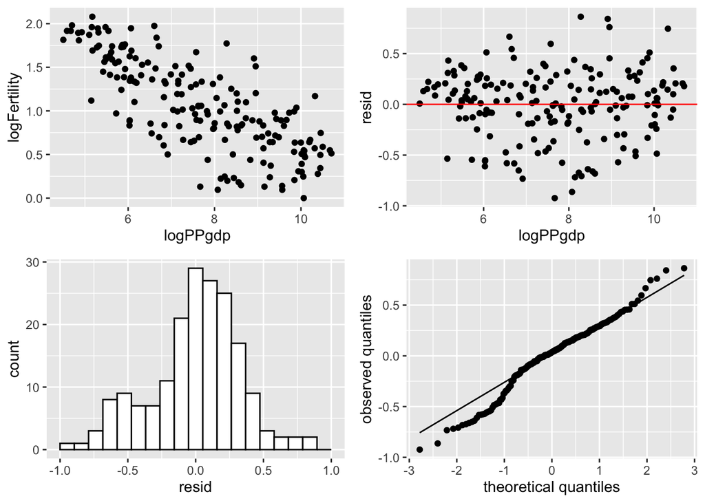

```r
gg1 = ggplot(un, aes(x = logPPgdp, y = logFertility)) +
  geom_point()

model=lm(logFertility~logPPgdp, data = un)
un$resid = model$residuals
sm=summary(model)


gg2 = ggplot(un) +
  geom_point(aes(x = logPPgdp, y = resid)) +
  geom_hline(aes(yintercept = 0), color = "red")




gg3 = ggplot(un, aes(x = resid)) +
  geom_histogram(bins = 20, color = "black", fill = "white") +
  xlim(c(-1,1))

gg4 = ggplot(un, aes(sample = resid))
gg4 = gg4 +
  stat_qq() +
  stat_qq_line() +
  xlab("theoretical quantiles") +
  ylab("observed quantiles")




library(ggpubr)
ggarrange(gg1, gg2, gg3, gg4, nrow = 2, ncol = 2)
```

```r
summary(model)
```

```
##
## Call:
## lm(formula = logFertility ~ logPPgdp, data = un)
##
## Residuals:
##      Min       1Q   Median       3Q      Max
## -0.92398 -0.16996  0.03671  0.20633  0.86331
##
## Coefficients:
##             Estimate Std. Error t value Pr(>|t|)
## (Intercept)  2.87607    0.11715   24.55   <2e-16 ***
## logPPgdp    -0.23749    0.01494  -15.90   <2e-16 ***
## ---
## Signif. codes:  0 '***' 0.001 '**' 0.01 '*' 0.05 '.' 0.1 ' ' 1
##
## Residual standard error: 0.3377 on 182 degrees of freedom
## Multiple R-squared:  0.5813, Adjusted R-squared:  0.579
## F-statistic: 252.7 on 1 and 182 DF,  p-value: < 2.2e-16
```

```r
t=(betahat1-0)/(sqrt(sm$sigma^2/SSX))
pt(t, df=n-2)
```

```
## [1] 1.502436e-36
```

The t-statistic for the slope coefficient is -15.9 with a p-value of nearly 0 so we reject at the $\alpha$-level 0.05. We have enough evidence to suspect that there is indeed a linear relationship between the transformed variables.

## 99% confidence interval on the expected Fertility for a region with PPgdp 20,000 US dollars in 2001

```r
newdata=data.frame(logPPgdp=log(20000))
plog=predict(model,newdata,interval="confidence",level=.99)
plog[2:3]
```

```
## [1] 0.4155429 0.6327373
```

```r
exp(plog[2:3]) #99% CI
```

```
## [1] 1.515193 1.882757
```

```r
#by hand
sigmahat2=sm$sigma^2
yhat=function(xh){
  betahat0+betahat1*xh}
seyhat=function(xh){
  sqrt(sigmahat2*(1/n + (xh-xbar)^2/sum((x-xbar)^2)))}
CI=yhat(xh=log(20000))+c(-1,1)*qt(.995,df=n-2)*seyhat(xh=log(20000))
exp(CI) #99% CI
```

```
## [1] 1.515193 1.882757
```

We’re 99% confident that the true mean logFertility for a region with PPGDP=$20,000 in 2001 is between (0.4155, 0.6327). This corresponds to an untransformed Fertility level between (1.5152, 1.8828) children per 1000 females.

## 95% confidence band for the relation between the expected Fertility and PPgdp

```r
W=sqrt(2*qf(.95, df1=2, df2=n-2))

yhat=function(x){
  betahat0+betahat1*x
}
sigmahat2=sm$sigma^2

#CI
seyhat=function(xh){
  sqrt(sigmahat2*(1/n + (xh-xbar)^2/sum((x-xbar)^2)))}

cband=function(xvec){
  d=length(xvec)
  CIs=matrix(0,d,3)
  colnames(CIs)=c("x","lower","upper")
  for(i in 1:d){
    CIs[i,]=c(xvec[i], yhat(x=xvec[i])+c(-1,1)*W*seyhat(xh=xvec[i]))
  }
  as.data.frame(CIs)
}

#make a grid over the range of x
range=seq(from=min(x),to=max(x),length.out = 100)
#calc conf bands at gridpoints
bands=cband(range)
#sanity check
head(bands)
```

```
##          x    lower    upper
## 1 4.499810 1.675627 1.939240
## 2 4.562489 1.662782 1.922315
## 3 4.625167 1.649927 1.905399
## 4 4.687846 1.637063 1.888492
## 5 4.750525 1.624189 1.871596
## 6 4.813204 1.611304 1.854710
```

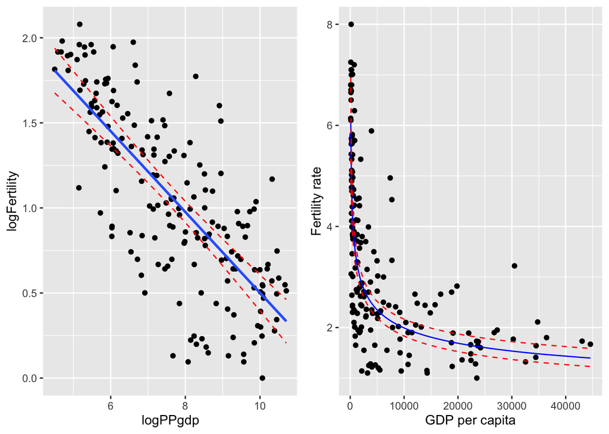

```r
#add bands to plot
ggtrans = ggplot(un, aes(x = logPPgdp, y = logFertility)) +
  geom_point() +
  geom_smooth(method = "lm",
              se = FALSE) +
  geom_line(data = bands,
            aes(x = x,
                y = lower),
                color = "red",
                linetype = "dashed") +
  geom_line(data = bands,
            aes(x = x,
                y = upper),
                color = "red",
                linetype = "dashed")

#add fitted vals
un$fitted = model$fitted.values
gguntrans = ggplot(un, aes(x = exp(logPPgdp), y = exp(logFertility))) +
  geom_point() +
  geom_line(aes(x = exp(logPPgdp),
                y = exp(fitted)),
            color = "blue") +
  geom_line(data = bands,
            aes(x = exp(x),
                y = exp(lower)),
            color = "red",
            linetype = "dashed") +
  geom_line(data = bands,
            aes(x = exp(x),
                y = exp(upper)),
            color = "red",
            linetype = "dashed") +
  xlab("GDP per capita") +
  ylab("Fertility rate")

ggarrange(ggtrans, gguntrans)
```

## 99% prediction interval on Fertility for a region with PPgdp 25,000 US dollars in 2018

```r
newdata=data.frame(logPPgdp=log(25000))
plog=predict(model,newdata,interval="prediction",level=.99)
plog[2:3]
```

```
## [1] -0.415426  1.357720
```

```r
exp(plog[2:3])
```

```
## [1] 0.6600591 3.8873186
```

```r
#by hand
yhat=function(xh){
  betahat0+betahat1*xh}
senewyhat=function(xh){
  sqrt(sigmahat2*(1+1/n + (xh-xbar)^2/sum((x-xbar)^2)))}
PI=yhat(xh=log(25000))+c(-1,1)*qt(.995,df=n-2)*senewyhat(xh=log(25000))
PI
```

```
## [1] -0.415426  1.357720
```

```r
exp(PI)
```

```
## [1] 0.6600591 3.8873186
```

We’re 99% confident that a new observation of a region with PPGDP=$25,000 in 2018 would have logFertility levels between (-0.415426, 1.357720). This corresponds to an untransformed Fertility level between (0.6601, 3.8873) births per 1000 females.